# Schools matter: the importance of school factors in explaining academic performance.

## Preliminary Wrangling

> The Program for International Student Assessment (PISA) is a worldwide study developed by the Organization for Economic Co-operation and Development (OECD) which examines the skills of 15-year-old school students around the world. The study assesses students' mathematics, science, and reading skills and contains a wealth of information on students' background, their school and the organization of education systems. For most countries, the sample is around 5,000 students, but in some countries the number is even higher. In total, the PISA 2012 dataset contains data on 485 490 pupils.

```python
# import all packages and set plots to be embedded inline
import numpy as np
import pandas as pd
import matplotlib.pyplot as plt
import seaborn as sb
import statsmodels.api as sm


%matplotlib inline
```

> Load in your dataset and describe its properties through the questions below. Try and motivate your exploration goals through this section.

```python
#loading data
pisa = pd.read_csv('pisa2012.csv', encoding='latin-1') #file size is 2.75 GB

pisa.size
```

```
308771640
```

```python
pisa.columns
```

```
Index(['Unnamed: 0', 'CNT', 'SUBNATIO', 'STRATUM', 'OECD', 'NC', 'SCHOOLID',
       'STIDSTD', 'ST01Q01', 'ST02Q01',
       ...
       'W_FSTR75', 'W_FSTR76', 'W_FSTR77', 'W_FSTR78', 'W_FSTR79', 'W_FSTR80',
       'WVARSTRR', 'VAR_UNIT', 'SENWGT_STU', 'VER_STU'],
      dtype='object', length=636)
```

- Dataset has too many columns and with no descriptive names.
- Using `pisadict2012.csv` in Excel spreadsheet to identify columns and select features of interest for analysis.

The dataset contains informations about school, student's grades and motivations, student_teacher relation

**There is multiple columns representing student grade for each subject, this will require creating new column with the average value for each of the 3 subjects.**

```python
#creating new columns with average grade for each subject

pisa['math']=pisa[['PV1MATH','PV2MATH','PV3MATH','PV4MATH','PV5MATH']].mean(axis=1)
pisa['reading']=pisa[['PV1READ','PV2READ','PV3READ','PV4READ','PV5READ']].mean(axis=1)
pisa['science']=pisa[['PV1SCIE','PV2SCIE','PV3SCIE','PV4SCIE','PV5SCIE']].mean(axis=1)
```

- Create dictionary of features of interest with the column name as key and new descriptive name as value.
- Copy columns to a new dataframe `pisa_red`.
- rename columns.

```python
#create dictionary with pisa columns and new descriptive names
cols = {'CNT':'country',
        'SCHOOLID':'school_id',
        'STIDSTD':'student_id',
        'ST01Q01':'international_grade',
        'ST04Q01':'gender',
        'AGE':'age',
        'CLSMAN':'m_class_management',
        'DISCLIMA':'disciplinary_cli',
        'EXAPPLM':'applied_math_exp',
        'EXPUREM':'pure_math_exp',
        'ANCATSCHL':'sch_att_outcome',
        'ANCATTLNACT':'sch_att_activity',
        'ANCBELONG':'sch_belonging',
        'ANCCOGACT':'math_cog_activation',
        'ANCMTSUP':'math_techer_supp',
        'ANCSCMAT':'math_self_concept',
        'ANCSTUDREL':'teacher_student',
        'ST25Q01':'home_lang',
        'ST26Q10':'textbook',
        'math':'math',
        'science':'science',
        'reading':'reading',
        'USESCH':'ict',
        'WEALTH':'wealth',
        'ESCS':'ESCS',
        'HEDRES':'h_edu_res',
        'HOMEPOS':'home_poss',
       }

# create list of pisa columns names to be copied:
col_list = list(cols.keys())
```

```python
#copy columns to new dataframe:
pisa_red = pisa[col_list].copy()

#rename columns with more descriptive names:
pisa_red.rename(columns=cols, inplace=True)

#view dataframe:
pisa_red.head()
```

|  | country | school_id | student_id | international_grade | gender | age | m_class_management | disciplinary_cli | applied_math_exp | pure_math_exp | ... | home_lang | textbook | math | science | reading | ict | wealth | ESCS | h_edu_res | home_poss |
| --- | --- | --- | --- | --- | --- | --- | --- | --- | --- | --- | --- | --- | --- | --- | --- | --- | --- | --- | --- | --- | --- |
| 0 | Albania | 1 | 1 | 10 | Female | 16.17 | -1.3771 | 1.85 | NaN | NaN | ... | Language of the test | Yes | 366.18634 | 371.91348 | 261.01424 | NaN | -2.92 | NaN | -1.29 | -2.61 |
| 1 | Albania | 1 | 2 | 10 | Female | 16.17 | NaN | NaN | -0.0681 | 0.7955 | ... | Language of the test | Yes | 470.56396 | 478.12382 | 384.68832 | NaN | 0.69 | NaN | 1.12 | 1.41 |
| 2 | Albania | 1 | 3 | 9 | Female | 15.58 | NaN | NaN | 0.5359 | 0.7955 | ... | Language of the test | Yes | 505.53824 | 486.60946 | 405.18154 | NaN | -0.23 | NaN | -0.69 | 0.14 |
| 3 | Albania | 1 | 4 | 9 | Female | 15.67 | NaN | 1.80 | 0.3220 | 0.7955 | ... | Language of the test | Yes | 449.45476 | 453.97240 | 477.46376 | NaN | -1.17 | NaN | 0.04 | -0.73 |
| 4 | Albania | 1 | 5 | 9 | Female | 15.50 | -0.0784 | -0.08 | NaN | NaN | ... | Language of the test | Yes | 385.50398 | 367.15778 | 256.01010 | NaN | -1.17 | NaN | -0.69 | -0.57 |

5 rows × 27 columns

```python
pisa_red.info()
```

```
<class 'pandas.core.frame.DataFrame'>
RangeIndex: 485490 entries, 0 to 485489
Data columns (total 27 columns):
 #   Column               Non-Null Count   Dtype
---  ------               --------------   -----
 0   country              485490 non-null  object
 1   school_id            485490 non-null  int64
 2   student_id           485490 non-null  int64
 3   international_grade  485490 non-null  int64
 4   gender               485490 non-null  object
 5   age                  485374 non-null  float64
 6   m_class_management   312708 non-null  float64
 7   disciplinary_cli     314777 non-null  float64
 8   applied_math_exp     313279 non-null  float64
 9   pure_math_exp        312602 non-null  float64
```

[output cut: 19 more lines]

```python
pisa_red.isna().sum()
```

```
country                     0
school_id                   0
student_id                  0
international_grade         0
gender                      0
age                       116
m_class_management     172782
disciplinary_cli       170713
applied_math_exp       172211
pure_math_exp          172888
sch_att_outcome        178655
sch_att_activity       179003
sch_belonging          177850
math_cog_activation    177340
math_techer_supp       176859
math_self_concept      178542
teacher_student        177432
home_lang               19994
textbook                14248
math                        0
science                     0
reading                     0
ict                    192905
wealth                   5893
ESCS                    11842
h_edu_res                7718
home_poss                5683
dtype: int64
```

- **The dataset have a lot of NULL values that will interfere in the final conclusion, However we will not delete nulls for now because this will delete almost half of the data.**
- **Instead we will fill NAN values in numeric columns with the average value for each country.**

```python
#create a list with all numeric columns that hae NANs:
_lis2 = [ 'm_class_management', 'disciplinary_cli', 'applied_math_exp', 'pure_math_exp',
         'sch_att_outcome','sch_att_activity', 'sch_belonging', 'math_cog_activation',
         'math_techer_supp', 'math_self_concept', 'teacher_student','ict']

#create a loop to iterate through columns list and replace NANs with mean value for each school:
for var in _lis2:
    pisa_red[var]=pisa_red.groupby('country')[var].apply(lambda x:x.fillna(x.mean()))
```

```python
pisa_red['ict'].fillna(pisa_red['ict'].mean(),inplace=True)
```

```python
#test and sum the remaining NAN values:
pisa_red.isna().sum().sum()
```

```
65494
```

- **Drop the remaining NAN values:**

```python
#drop NA:
pisa_red.dropna(inplace=True)
#test:
pisa_red.isna().sum().sum()
```

```
0
```

Country Variable has more than one value to represent USA

```python
_lis3 = ['Florida (USA)', 'Connecticut (USA)', 'Massachusetts (USA)', 'United States of America']

pisa_red.replace(to_replace =_lis3, value ="USA", inplace=True)
```

Remove Outliers

```python
pisa_red = pisa_red[pisa_red.international_grade != 96]
```

Check for duplicates

```python
pisa_red.duplicated().sum()
```

```
0
```

- **Save cleaned Dataframe to CSV file**

```python
#save new dataframe as csv file
pisa_red.to_csv('pisa_clean.csv',index=False)
```

### Dataset Structure

> PISA 2012 dataset contains data on 485,490 pupils. The dataset contains students' grades in mathematics, science, and reading skills and contains a wealth of information on students' background, their school and the organization of education systems. spread into 636 columns.

### Main feature(s) of interest in dataset:

> School performance is an issue that deeply concerns students, parents,teachers and authorities.  
> in this analysis we will be interested in finding out how schools matters, the importance of school factors in explaining academic performance. main features of interest in this analysis are copied to new csv file `pisa_clean.csv`, and falls into 2 major groups:  
> 1) student's interests and interactions to school.  
> 2) School factors

## Univariate Exploration

> In this section, investigate distributions of individual variables. If you see unusual points or outliers, take a deeper look to clean things up and prepare yourself to look at relationships between variables.

```python
df = pd.read_csv('pisa_clean.csv')
df.shape
```

```
(449700, 27)
```

```python
df.describe()
```

|  | school_id | student_id | international_grade | age | m_class_management | disciplinary_cli | applied_math_exp | pure_math_exp | sch_att_outcome | sch_att_activity | ... | math_self_concept | teacher_student | math | science | reading | ict | wealth | ESCS | h_edu_res | home_poss |
| --- | --- | --- | --- | --- | --- | --- | --- | --- | --- | --- | --- | --- | --- | --- | --- | --- | --- | --- | --- | --- | --- |
| count | 449700.000000 | 449700.000000 | 449700.000000 | 449700.000000 | 449700.000000 | 449700.000000 | 449700.000000 | 449700.000000 | 449700.000000 | 449700.000000 | ... | 449700.000000 | 449700.000000 | 449700.000000 | 449700.000000 | 449700.000000 | 449700.000000 | 449700.000000 | 449700.000000 | 449700.000000 | 449700.000000 |
| mean | 241.485968 | 6165.830571 | 9.670727 | 15.783809 | 0.083474 | 0.001764 | -0.002810 | -0.004024 | -0.025819 | -0.038323 | ... | -0.041089 | -0.003069 | 474.706828 | 481.098253 | 477.696480 | -0.028485 | -0.330842 | -0.255759 | -0.183140 | -0.314952 |
| std | 279.697372 | 6757.062130 | 0.746686 | 0.290162 | 0.806752 | 0.811089 | 0.820788 | 0.800596 | 0.807618 | 0.818492 | ... | 0.795377 | 0.811666 | 99.505254 | 96.129418 | 96.296914 | 0.787464 | 1.211837 | 1.130701 | 1.071671 | 1.159974 |
| min | 1.000000 | 1.000000 | 7.000000 | 15.250000 | -3.253000 | -2.480000 | -2.986800 | -2.733400 | -2.777900 | -2.609000 | ... | -2.013400 | -2.665800 | 78.836260 | 25.158540 | 6.445400 | -1.610400 | -6.650000 | -5.660000 | -3.930000 | -6.880000 |
| 25% | 61.000000 | 1819.000000 | 9.000000 | 15.580000 | -0.259971 | -0.330000 | -0.360977 | -0.302973 | -0.246286 | -0.327651 | ... | -0.260482 | -0.221700 | 401.627960 | 412.010460 | 411.933180 | -0.138800 | -1.040000 | -0.990000 | -0.690000 | -0.970000 |
| 50% | 137.000000 | 3756.000000 | 10.000000 | 15.750000 | -0.015815 | -0.026668 | 0.006364 | 0.102345 | 0.027132 | -0.030880 | ... | -0.021200 | 0.011100 | 470.953420 | 480.734820 | 480.773840 | -0.022295 | -0.290000 | -0.180000 | 0.040000 | -0.230000 |
| 75% | 294.000000 | 7515.000000 | 10.000000 | 16.000000 | 0.325500 | 0.372836 | 0.322000 | 0.795500 | 0.191049 | 0.260836 | ... | 0.266201 | 0.254391 | 544.407240 | 550.391640 | 546.648160 | 0.353000 | 0.430000 | 0.620000 | 1.120000 | 0.400000 |
| max | 1471.000000 | 33806.000000 | 13.000000 | 16.330000 | 2.198900 | 1.850000 | 3.203900 | 0.795500 | 3.042300 | 2.000900 | ... | 2.807300 | 2.821100 | 903.107960 | 857.832900 | 849.359740 | 4.109900 | 3.250000 | 3.690000 | 1.120000 | 4.150000 |

8 rows × 23 columns

## How is gender distribution in the dataset?

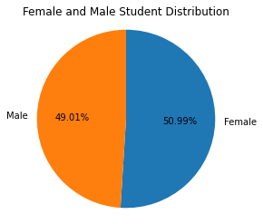

```python
#plot pie chart of female and male students distribution:
data = df['gender'].value_counts()
plt.pie(data,labels = data.index, startangle = 90, counterclock = False, autopct='%1.2f%%')
plt.title('Female and Male Student Distribution')
plt.axis('square');
```

Female students are slightly more represented than male students,but Overall dataset can be considered unbiased.

## What are the countries represented and how is the student distributed?

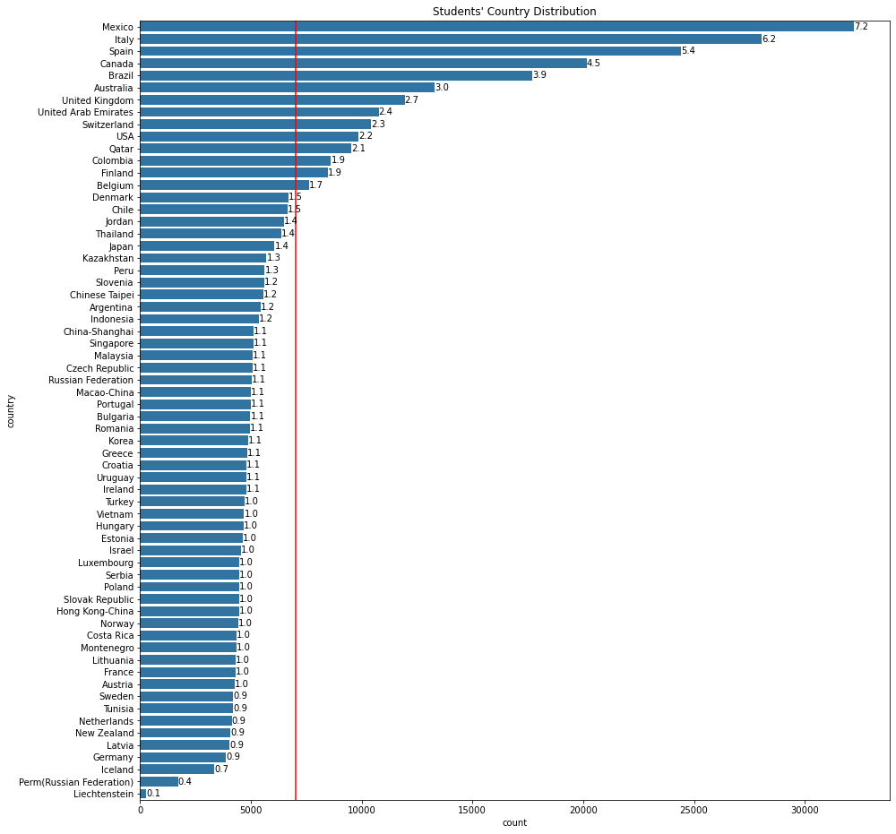

```python
# plot Students' Country distribution:
base_color = sb.color_palette()[0]
plt.figure(figsize=(15,16))

freq = df['country'].value_counts().index
sb.countplot(data= df, y='country',order=freq, color=base_color)

type_counts = df['country'].value_counts()
for i in range (type_counts.shape[0]):
    count = type_counts[i]
    # Convert count into a percentage, and then into string
    pct_string = '{:0.1f}'.format(100*count/df.shape[0])
    # Print the string value on the bar.
    plt.text(count+1, i, pct_string, va='center')

plt.axvline(type_counts.mean(), c='red')
plt.title("Students' Country Distribution");
```

## Bivariate Exploration

> In this section, investigate relationships between pairs of variables in your data. Make sure the variables that you cover here have been introduced in some fashion in the previous section (univariate exploration).

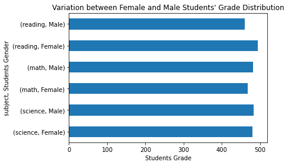

```python
df.groupby('gender')[['science','math','reading']].mean().unstack('gender').plot(kind='barh',rot=0,
                                                                                        width=0.5,)

plt.title("Variation between Female and Male Students' Grade Distribution")
plt.xlabel('Students Grade')
plt.ylabel('subject, Students Gender');
```

While both female and male students have equal grade mean in science, Female students score higher grades in reading and Male students score higher in math

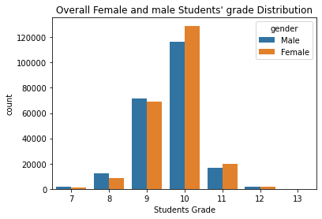

```python
sb.countplot(data = df, x = 'international_grade', hue = 'gender')
plt.title("Overall Female and male Students' grade Distribution")
plt.xlabel('Students Grade');
```

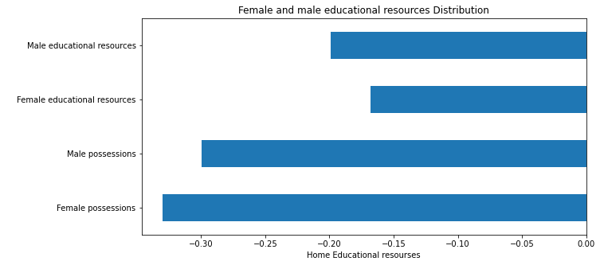

```python
#plotting students gender with mean educational resources& home possessions
plt.figure(figsize=(10,5))
df.groupby('gender')[['home_poss','h_edu_res']].mean().unstack('gender').plot(kind='barh',rot=0,width=0.5,)
#setting title and axes
plt.title("Female and male educational resources Distribution")
yt = ['Female possessions','Male possessions' ,'Female educational resources','Male educational resources']
plt.yticks([0,1,2,3],yt)
plt.ylabel(' ')
plt.xlabel('Home Educational resourses');
```

## What is grade distribution in each country

```
(6.5, 15.0)
```

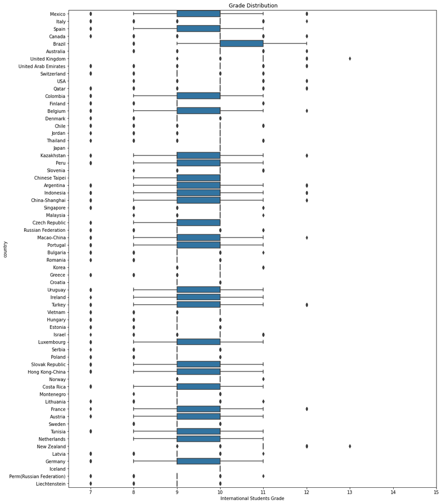

```python
plt.figure(figsize=(15,20))
freq = df['country'].value_counts().index

sb.boxplot(data=df, x='international_grade', y='country',order=freq, color=base_color);

plt.title(" Grade Distribution")
plt.xlabel('International Students Grade')
plt.xlim(6.5,15)
```

By looking at this graph, it's noticed that grade distribution is almost the same in all countries except for Brazil has the highest grades

## Multivariate Exploration

> Create plots of three or more variables to investigate your data even further. Make sure that your investigations are justified, and follow from your work in the previous sections.

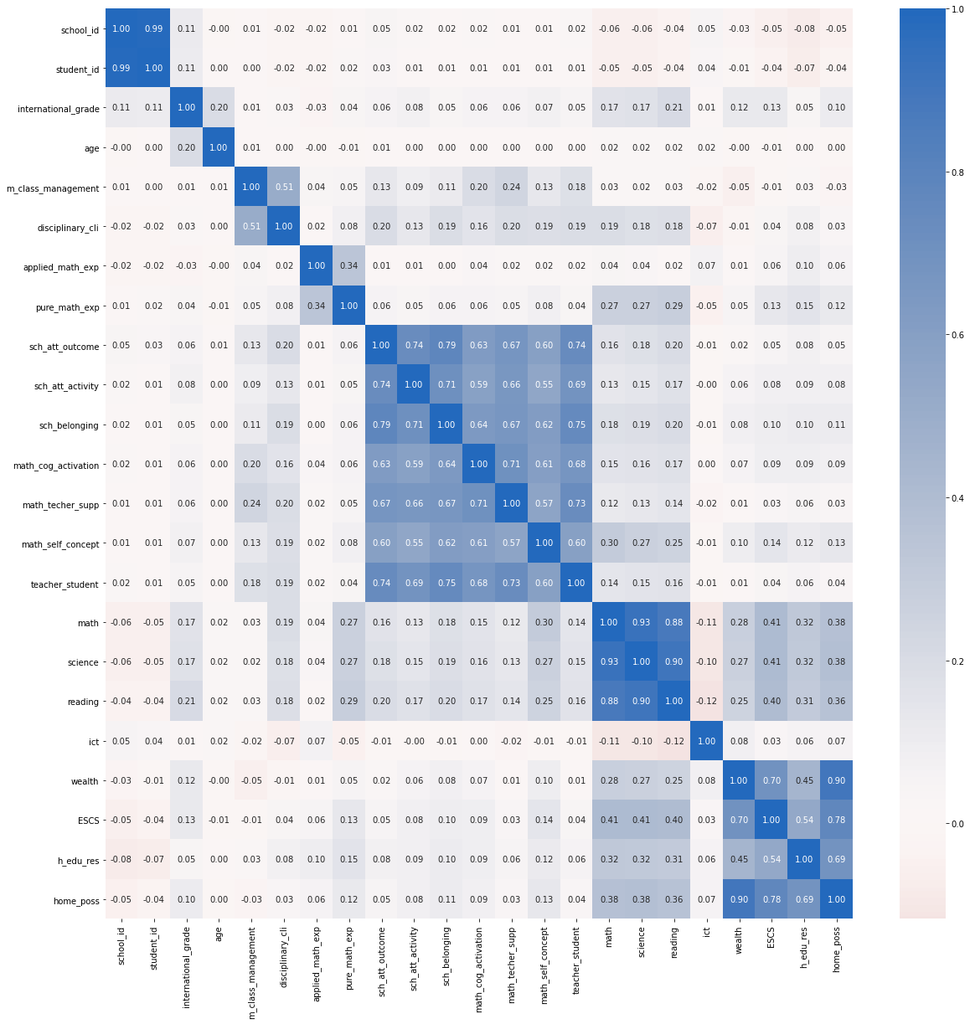

```python
plt.figure(figsize=(20,20))

sb.heatmap(df.corr(), annot = True, fmt = '.2f', cmap = 'vlag_r', center = 0)
```

### The Impact of Inequality

```python
df.school_id.value_counts()
```

```
28      2417
24      2250
35      2205
12      2074
41      2065
        ...
1468       1
1256       1
1342       1
1466       1
1260       1
Name: school_id, Length: 1470, dtype: int64
```

School_id column resets for each country, we need to create new column with unique id for each school

```python
# School_id column resets for each country

#Change dtype of school_id:
df['school_id'] = df['school_id'].astype(str)

#Create new column with unique id for each school
df['school']= df['country']+df['school_id']
```

```python
#create new column with average grade for all 3 subjects
df['grade']=df[['math','science','reading']].mean(axis=1)
```

# How does School Factors affect Student Grade

### There is more than few school attributes in this dataset, We will select relevant factors in three main groups:

- School_Student Relation.
- Math Classroom Factors.
- General School Factors.

To Compare between difference in School attribute and students grade , We first need to create new dataframe with average value for each school

```python
#create new df with school average value:
df2 = df.groupby('school').mean()

df2.describe()
```

|  | student_id | international_grade | age | m_class_management | disciplinary_cli | applied_math_exp | pure_math_exp | sch_att_outcome | sch_att_activity | sch_belonging | ... | teacher_student | math | science | reading | ict | wealth | ESCS | h_edu_res | home_poss | grade |
| --- | --- | --- | --- | --- | --- | --- | --- | --- | --- | --- | --- | --- | --- | --- | --- | --- | --- | --- | --- | --- | --- |
| count | 17880.000000 | 17880.000000 | 17880.000000 | 17880.000000 | 17880.000000 | 17880.000000 | 17880.000000 | 17880.000000 | 17880.000000 | 17880.000000 | ... | 17880.000000 | 17880.000000 | 17880.000000 | 17880.000000 | 17880.000000 | 17880.000000 | 17880.000000 | 17880.000000 | 17880.000000 | 17880.000000 |
| mean | 6486.092189 | 9.592582 | 15.776422 | 0.086290 | -0.007042 | -0.001477 | -0.034038 | -0.024736 | -0.041364 | -0.080981 | ... | 0.001276 | 466.249701 | 473.620037 | 468.435044 | 0.002831 | -0.389108 | -0.333265 | -0.231762 | -0.381310 | 469.434927 |
| std | 6993.487815 | 0.671455 | 0.120712 | 0.337544 | 0.368631 | 0.328771 | 0.346681 | 0.296992 | 0.301272 | 0.305266 | ... | 0.301564 | 77.891487 | 75.367483 | 76.341475 | 0.444819 | 0.937377 | 0.857509 | 0.637159 | 0.877257 | 74.874174 |
| min | 1.000000 | 7.000000 | 15.250000 | -2.433200 | -2.480000 | -2.986800 | -2.733400 | -2.777900 | -2.609000 | -3.373100 | ... | -2.665800 | 130.059220 | 92.409540 | 137.387007 | -1.610400 | -5.080000 | -4.540000 | -3.930000 | -6.480000 | 148.659165 |
| 25% | 1913.000000 | 9.000000 | 15.711071 | -0.133160 | -0.250197 | -0.199231 | -0.248829 | -0.187232 | -0.213157 | -0.244886 | ... | -0.179052 | 409.665641 | 419.345717 | 417.168396 | -0.143650 | -0.920381 | -0.809581 | -0.590554 | -0.863372 | 415.843109 |
| 50% | 3892.928571 | 9.764706 | 15.782799 | 0.075031 | -0.022333 | 0.013302 | 0.000982 | 0.000989 | -0.026099 | -0.052681 | ... | 0.006536 | 470.486056 | 479.423244 | 474.302464 | -0.022295 | -0.196548 | -0.187966 | -0.104868 | -0.172614 | 474.856382 |
| 75% | 8227.241071 | 10.000000 | 15.851034 | 0.289693 | 0.209687 | 0.202537 | 0.219178 | 0.161804 | 0.152012 | 0.114436 | ... | 0.186941 | 518.531894 | 527.502396 | 522.608323 | 0.202967 | 0.260916 | 0.277537 | 0.220000 | 0.219509 | 522.008014 |
| max | 33790.062500 | 12.000000 | 16.330000 | 2.198900 | 1.850000 | 3.203900 | 0.795500 | 3.042300 | 2.000900 | 3.255400 | ... | 2.821100 | 814.073177 | 734.078892 | 733.562251 | 4.109900 | 3.090000 | 2.200000 | 1.120000 | 3.820000 | 758.985171 |

8 rows × 23 columns

```python
df2.shape
```

```
(17880, 23)
```

## School_Student Relation:

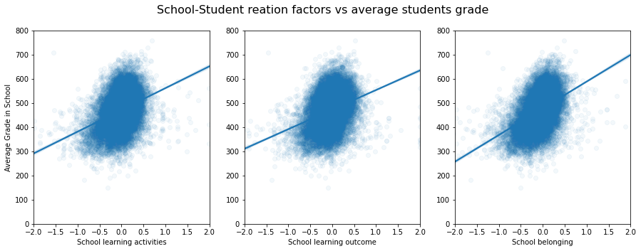

```python
plt.figure(figsize=(15,5))

plt.subplot(1,3,1)
sb.regplot(data = df2, y = 'grade', x = 'sch_att_outcome', scatter_kws={'alpha':1/20})
plt.ylim(0,800)
plt.xlim(-2,2)
plt.ylabel('Average Grade in School')
plt.xlabel('School learning activities')

plt.subplot(1,3,2)
sb.regplot(data = df2, y = 'grade', x = 'sch_att_activity', scatter_kws={'alpha':1/20})
plt.ylim(0,800)
plt.xlim(-2,2)
plt.ylabel('')
plt.xlabel('School learning outcome')


plt.subplot(1,3,3)
sb.regplot(data = df2, y = 'grade', x = 'sch_belonging', scatter_kws={'alpha':1/20})
plt.ylim(0,800)
plt.xlim(-2,2)
plt.ylabel('')
plt.xlabel('School belonging')


plt.suptitle('School-Student reation factors vs average students grade', fontsize=16)

# Display a figure.
plt.show();
```

#### Student attitude toward School have high influence in average students grade, specially Students' sense of belonging toward schools. This shows the importance of school environment in students' moral and grades

## General School Factors.

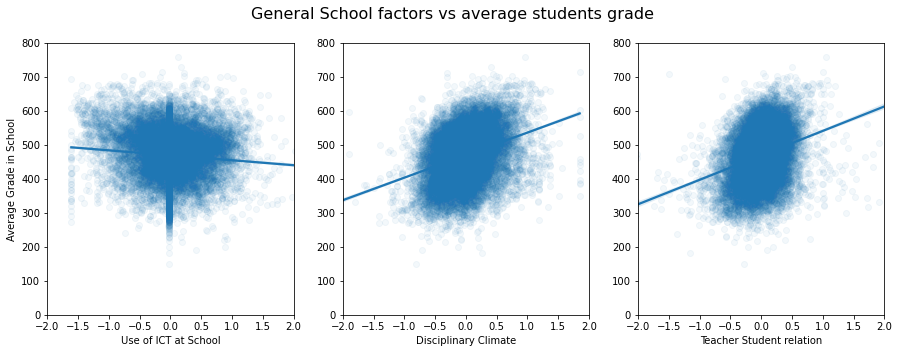

```python
plt.figure(figsize=(15,5))

plt.subplot(1,3,1)
sb.regplot(data = df2, y = 'grade', x = 'ict', scatter_kws={'alpha':1/20})
plt.ylim(0,800)
plt.xlim(-2,2)
plt.ylabel('Average Grade in School')
plt.xlabel('Use of ICT at School')

plt.subplot(1,3,2)
sb.regplot(data = df2, y = 'grade', x = 'disciplinary_cli', scatter_kws={'alpha':1/20})
plt.ylim(0,800)
plt.xlim(-2,2)
plt.ylabel(' ')
plt.xlabel('Disciplinary Climate')


plt.subplot(1,3,3)
sb.regplot(data = df2, y = 'grade', x = 'teacher_student', scatter_kws={'alpha':1/20})
plt.ylim(0,800)
plt.xlim(-2,2)
plt.ylabel(' ')
plt.xlabel('Teacher Student relation')


plt.suptitle('General School factors vs average students grade', fontsize=16)

# Display a figure.
plt.show();
```

#### What a surprise! Use of ICT "Information and Communications Technology" in school has inverse relation with grades Strict Disciplinary climate and good relation between teachers and students positively affect students grade

## Math Classroom Factors.

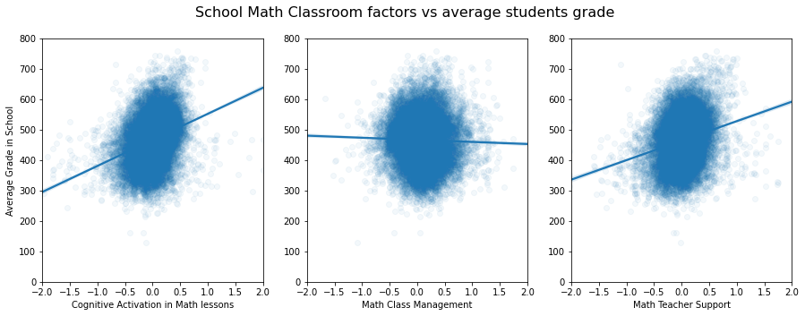

```python
plt.figure(figsize=(15,5))

plt.subplot(1,3,1)
sb.regplot(data = df2, y = 'math', x = 'math_cog_activation', scatter_kws={'alpha':1/20})
plt.ylim(0,800)
plt.xlim(-2,2)
plt.ylabel('Average Grade in School')
plt.xlabel("Cognitive Activation in Math lessons")

plt.subplot(1,3,2)
sb.regplot(data = df2, y = 'math', x = 'm_class_management', scatter_kws={'alpha':1/20})
plt.ylim(0,800)
plt.xlim(-2,2)
plt.ylabel('')
plt.xlabel('Math Class Management')


plt.subplot(1,3,3)
sb.regplot(data = df2, y = 'math', x = 'math_techer_supp', scatter_kws={'alpha':1/20})
plt.ylim(0,800)
plt.xlim(-2,2)
plt.ylabel('')
plt.xlabel('Math Teacher Support')


plt.suptitle('School Math Classroom factors vs average students grade', fontsize=16)

# Display a figure.
plt.show();
```

#### Math Teacher support and Cognitive activation in math lessons both positively affect students grade. It looks like math classroom management is centered but with slight negative correlation, Students need more freedom in asking questions and requesting elaboration.

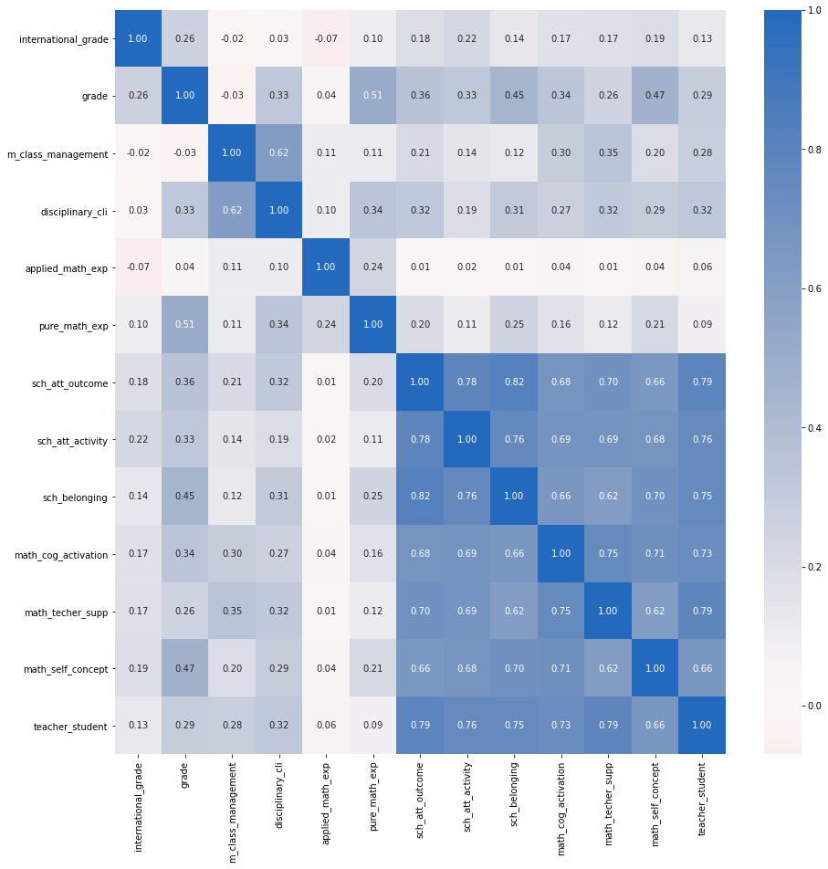

```python
plt.figure(figsize=(15,15))

sb.heatmap(df2[['international_grade' ,'grade', 'm_class_management'  ,'disciplinary_cli','applied_math_exp','pure_math_exp',
                    'sch_att_outcome' ,'sch_att_activity','sch_belonging' ,'math_cog_activation','math_techer_supp',
                    'math_self_concept','teacher_student']].corr(), annot = True, fmt = '.2f', cmap = 'vlag_r', center = 0)
```

## Schools and Teachers have important role to play towards learning capabilities of students. Their roles includes

- promoting active learning,
- promoting success.
- developing thinking skills.
- creating effective learning zones.
- Student support and providing effective feedback.
- developing good relationship.
- enhancing motivation.
- accepting individual differences.

## Learning is influenced by social interactions, interpersonal relations, and communication with others. Learning can be enhanced when the learner has an opportunity to interact and to collaborate with others on instructional tasks.